# **Analysis on 2020-2024 Data Science Salaries**

Spring 2025 Data Science Project

Jamal Bankole

Contributions: I worked alone

# **Introduction**

Data Science is a prominent and vast field that has increased over the last few years, as there's many opportunities lately to get into the field such as boot camps and tutorials. Knowing the changes in this field, how has the salary changed over the past years?

In this tutorial, we want to analyze the annual salary growth of the Data Science positions between 2020 and 2024. By doing so, we'll be able to understand the salary trends in the field. Knowing the salary trends keeps one ahead in the field as they have an idea of the positions that are earning the most, the competitiveness between the positions, and will be able to predict future growth. Futhermore, I want to predict the 2025 annual salary based off of the experience level and the job position.

# **Exploratory Data Analysis**

During the data collection stage, we will use websites to retrieve data. The [dataset](https://www.kaggle.com/datasets/saurabhbadole/latest-data-science-job-salaries-2024) that I'll be using contains over 50,000 entries of Data Science positions across different U.S. states over the past 5 years.

First, we will import Python libraries that will aid us during this tutorial. We will create a dataframe named **positions_df** using Pandas.

There's entries for 2025, but we will only consider positions for 2020 through 2024 to calculate the average annual salaries since 2025 isn't over yet.

We also want the company location and salary currency to be **exclusively** in the U.S.

The features that we won't need in salaries_df includes the following:

employment_type

employee_residence

salary_in_usd

remote_ratio

company_size.

```python
import pandas as pd
import math
import numpy as np
import matplotlib.pyplot as plt
import seaborn as sns
from scipy import stats
from scipy.stats import f_oneway
from sklearn.linear_model import LinearRegression
from sklearn.model_selection import train_test_split
from sklearn.metrics import mean_squared_error
from sklearn.metrics import r2_score as r2
from sklearn.preprocessing import StandardScaler

positions_df = pd.read_csv('DataScience_salaries_2025.csv')
positions_df = positions_df.drop(columns=['employment_type', 'employee_residence', 'salary_in_usd', 'remote_ratio', 'company_size'], axis=1)

positions_df = positions_df[positions_df['work_year'] < 2025]
positions_df = positions_df[positions_df['company_location'] == 'US']
positions_df = positions_df[positions_df['salary_currency'] == 'USD']

positions_df
```

|  | work_year | experience_level | job_title | salary | salary_currency | company_location |
| --- | --- | --- | --- | --- | --- | --- |
| 20849 | 2024 | SE | Data Developer | 131958 | USD | US |
| 20850 | 2024 | SE | Data Developer | 79175 | USD | US |
| 20851 | 2024 | MI | Manager | 280000 | USD | US |
| 20852 | 2024 | MI | Manager | 80000 | USD | US |
| 20853 | 2024 | EN | Analytics Engineer | 720000 | USD | US |
| ... | ... | ... | ... | ... | ... | ... |
| 93591 | 2021 | SE | Data Specialist | 165000 | USD | US |
| 93592 | 2020 | SE | Data Scientist | 412000 | USD | US |
| 93593 | 2021 | MI | Principal Data Scientist | 151000 | USD | US |
| 93594 | 2020 | EN | Data Scientist | 105000 | USD | US |
| 93595 | 2020 | EN | Business Data Analyst | 100000 | USD | US |

65529 rows × 6 columns

# **Basic Data Exploration and Summary Statistics**

\

The features that are in salaries_df are the following:

work_year : The work year of the position.

experience_level: The experience level of the position.

job_title: The job title of the position.

salary: The salary of the position.

salary_currency: The type of currency of the salary.

company_location: The company location of the position.

```python
#Let's see the amount of Data Science positions for each year

positions_groups = positions_df.groupby('work_year')

positions_groups['job_title'].count()
```

| work_year | job_title |
| --- | --- |
| 2020 | 32 |
| 2021 | 95 |
| 2022 | 1339 |
| 2023 | 7596 |
| 2024 | 56467 |

**dtype:** int64

We can see that there was a spike of Data Science positions in the U.S. during 2022. This could perhaps be due to the pandemic, where everyone was more online. More online time gave people the opportunity to engage in different fields such as Data Science. There was additionally another spike of Data Science positions during 2024 as there was about 7 times more positions available compared to the number of positions in 2023.

\

Within the years, let's observe the number of positions for each job title.

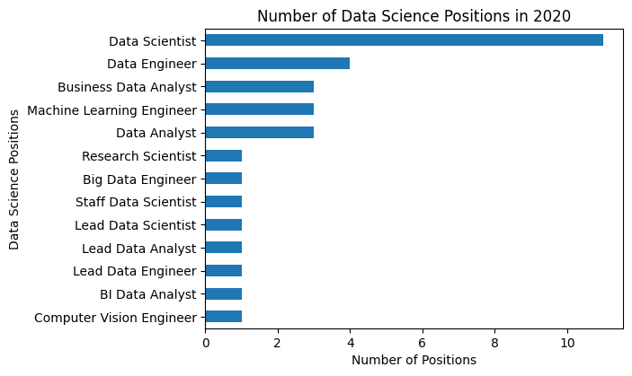

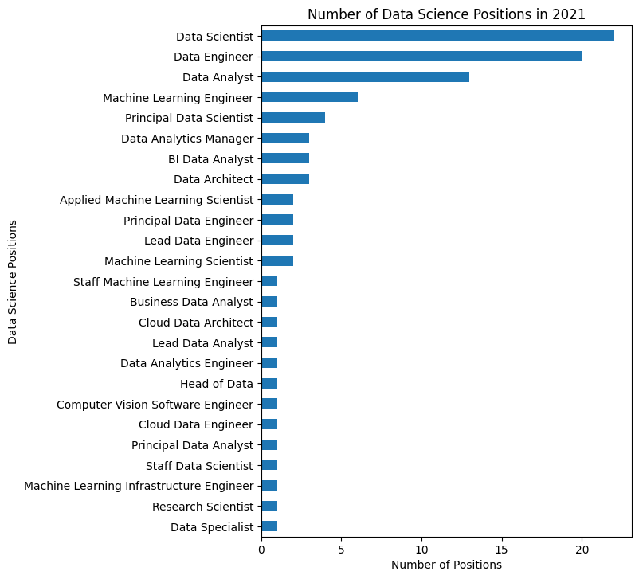

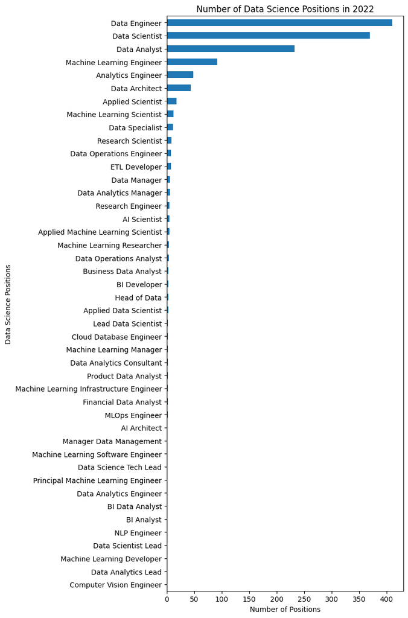

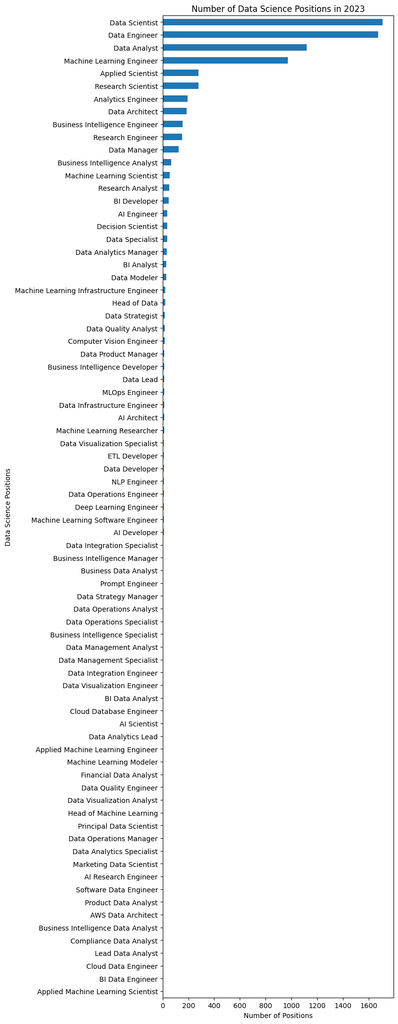

[figure not shown]

```python
for group in positions_groups:
  position_frequency = group[1]['job_title'].value_counts()

  position_frequency.iloc[::-1].plot(y='job_title', kind='barh', figsize=(6, position_frequency.count()/3))

  plt.ylabel('Data Science Positions')
  plt.xlabel('Number of Positions')

  plt.title('Number of Data Science Positions in ' + str(group[1]['work_year'].values[0]))
  plt.show()
```

As you can see from the bar plots, the popular Data Science jobs are the following due to the amount of positions:

Data Scientist

Data Engineer

Data Analyst

Machine Learning Engineer

**Statistical Method #1**

\

To visualize the difference in the salary growth between years, let's utilize a Pearson Correlation matrix between any of the features in the dataframe. Doing so will give us an idea of the salary growth within the Data Science field based on the correlation between the salary and the other features.

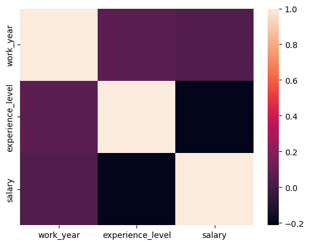

```python
# Changing the experience level to a numerical value
convert_experience = {'SE': 0, 'MI': 1, 'EN': 2, 'EX': 3}
experience_copy = positions_df['experience_level']
positions_df['experience_level'] = positions_df['experience_level'].map(convert_experience)
correlation_matrix = positions_df.corr(numeric_only=True)

sns.heatmap(correlation_matrix)
plt.show()

'''
scatter_matrix(correlation_matrix)
plt.show()
'''

positions_df['experience_level'] = experience_copy

#statistic, pvalue = pearsonr(positions_df['salary'], experience_numbers)
```

\

**Statistical Method #2**

\

Let's found the outliers of the salary within the Data Science positions.

```
Lower Quartile:  94000.0
Upper Quartile:  170000.0
Outliers:        work_year experience_level           job_title  salary salary_currency  \
88806       2020               EX      Data Scientist  300000             USD
93379       2020               MI  Research Scientist  450000             USD
93543       2020               EX      Data Scientist  325000             USD
93592       2020               SE      Data Scientist  412000             USD

      company_location
88806               US
93379               US
93543               US
93592               US

Number of Positions for Each Job Title

job_title
Data Scientist        3
Research Scientist    1
Name: count, dtype: int64


Experience Level of Outlier Positions in 2020: ['EX' 'MI' 'SE']
```

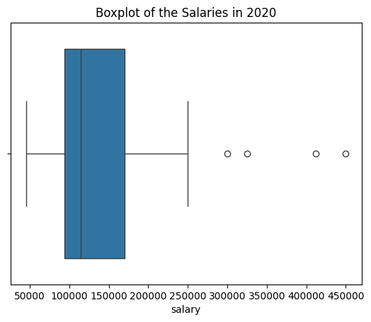

```
Lower Quartile:  90000.0
Upper Quartile:  174000.0
Outliers:        work_year experience_level                           job_title  salary  \
93524       2021               EX            Principal Data Scientist  416000
93589       2021               MI  Applied Machine Learning Scientist  423000

      salary_currency company_location
93524             USD               US
93589             USD               US

Number of Positions for Each Job Title

job_title
Principal Data Scientist              1
Applied Machine Learning Scientist    1
Name: count, dtype: int64


Experience Level of Outlier Positions in 2021: ['EX' 'MI']
```

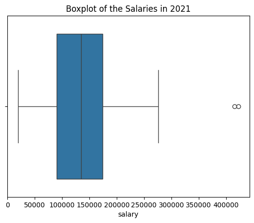

```
Lower Quartile:  112900.0
Upper Quartile:  180000.0
Outliers:        work_year experience_level                           job_title  salary  \
91145       2022               SE  Machine Learning Software Engineer  375000
91812       2022               EX                       Data Engineer  310000
92038       2022               SE                       Data Engineer  300000
92154       2022               EX                       Data Engineer  310000
92156       2022               SE                      Data Scientist  299500
92206       2022               SE                  Research Scientist  300000
92234       2022               SE              Data Science Tech Lead  375000
92249       2022               SE                      Data Scientist  350000
92280       2022               SE                       Data Engineer  315000
92375       2022               SE                       Data Engineer  300000
92428       2022               SE                      Data Architect  345600
92541       2022               SE                       Data Engineer  300000
92700       2022               EX                       Data Engineer  297500
92723       2022               SE                       Data Engineer  300000
93012       2022               SE                      Data Scientist  300000
93270       2022               EX                       Data Engineer  324000
93322       2022               SE                 Data Analytics Lead  405000
93327       2022               SE              Applied Data Scientist  380000

      salary_currency company_location
91145             USD               US
91812             USD               US
92038             USD               US
92154             USD               US
92156             USD               US
92206             USD               US
92234             USD               US
92249             USD               US
92280             USD               US
92375             USD               US
92428             USD               US
92541             USD               US
92700             USD               US
92723             USD               US
93012             USD               US
93270             USD               US
93322             USD               US
93327             USD               US

Number of Positions for Each Job Title

job_title
Data Engineer                         9
Data Scientist                        3
Machine Learning Software Engineer    1
Research Scientist                    1
Data Science Tech Lead                1
Data Architect                        1
Data Analytics Lead                   1
Applied Data Scientist                1
Name: count, dtype: int64


Experience Level of Outlier Positions in 2022: ['SE' 'EX']
```

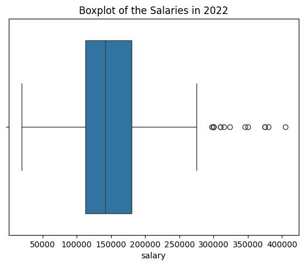

```
Lower Quartile:  115934.0
Upper Quartile:  196000.0
Outliers:        work_year experience_level                   job_title  salary  \
83411       2023               SE               Data Engineer  333500
83469       2023               MI  Machine Learning Scientist  750000
83475       2023               MI   Machine Learning Engineer  750000
83477       2023               SE    Computer Vision Engineer  351000
83594       2023               SE   Machine Learning Engineer  319000
...          ...              ...                         ...     ...
91005       2023               SE   Machine Learning Engineer  323300
91173       2023               SE   Machine Learning Engineer  318300
91175       2023               SE                Data Analyst  385000
91198       2023               SE          Research Scientist  370000
91307       2023               SE           Applied Scientist  350000

      salary_currency company_location
83411             USD               US
83469             USD               US
83475             USD               US
83477             USD               US
83594             USD               US
...               ...              ...
91005             USD               US
91173             USD               US
91175             USD               US
91198             USD               US
91307             USD               US

[119 rows x 6 columns]

Number of Positions for Each Job Title

job_title
Machine Learning Engineer       40
Data Scientist                  26
Data Engineer                   11
Research Scientist              10
Research Engineer                6
AI Architect                     4
Head of Data                     4
AI Engineer                      3
Machine Learning Scientist       2
Computer Vision Engineer         2
Data Architect                   2
Analytics Engineer               2
Deep Learning Engineer           2
Head of Machine Learning         1
Data Infrastructure Engineer     1
Data Lead                        1
Data Analyst                     1
Applied Scientist                1
Name: count, dtype: int64


Experience Level of Outlier Positions in 2023: ['SE' 'MI' 'EN' 'EX']
```

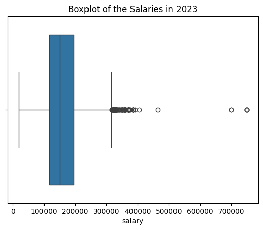

```
Lower Quartile:  113000.0
Upper Quartile:  204000.0
Outliers:        work_year experience_level                   job_title  salary  \
20853       2024               EN          Analytics Engineer  720000
20855       2024               MI          Analytics Engineer  720000
20857       2024               MI          Analytics Engineer  720000
20859       2024               MI          Analytics Engineer  700000
20865       2024               MI           Research Engineer  720000
...          ...              ...                         ...     ...
82871       2024               MI  Machine Learning Scientist  750000
82875       2024               SE           Research Engineer  440000
82901       2024               MI           Research Engineer  720000
82911       2024               MI          Research Scientist  720000
82915       2024               MI           Research Engineer  720000

      salary_currency company_location
20853             USD               US
20855             USD               US
20857             USD               US
20859             USD               US
20865             USD               US
...               ...              ...
82871             USD               US
82875             USD               US
82901             USD               US
82911             USD               US
82915             USD               US

[1099 rows x 6 columns]

Number of Positions for Each Job Title

job_title
Machine Learning Engineer                203
Software Engineer                        185
Research Scientist                        96
Engineer                                  91
Research Engineer                         81
Data Scientist                            69
Engineering Manager                       56
```

[output cut: 39 more lines]

```
Security Engineer                          1
Data Product Manager                       1
Machine Learning Performance Engineer      1
Robotics Engineer                          1
Full Stack Engineer                        1
Lead Engineer                              1
AI Researcher                              1
Data Governance Engineer                   1
Business Intelligence                      1
Machine Learning Developer                 1
Machine Learning Manager                   1
Name: count, dtype: int64


Experience Level of Outlier Positions in 2024: ['EN' 'MI' 'SE' 'EX']
```

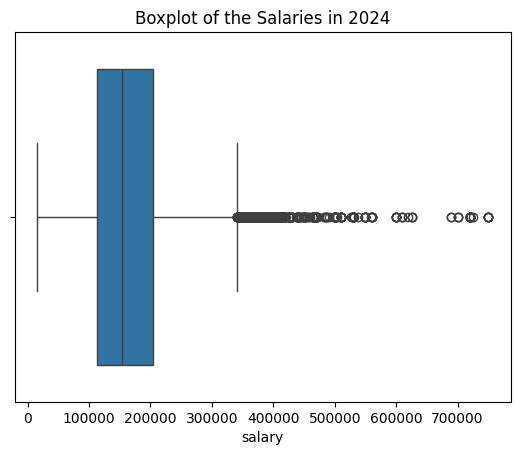

```python
for group in positions_groups:
  sns.boxplot(x=group[1]['salary'])

  q1 = group[1]['salary'].quantile(0.25)
  q3 = group[1]['salary'].quantile(0.75)
  iqr = q3 - q1

  upper_bound = q3 + 1.5 * iqr
  lower_bound = q1 - 1.5 * iqr

  print("Lower Quartile: ", q1)
  print("Upper Quartile: ", q3)

  outliers = group[1][(group[1]['salary'] < lower_bound) | (group[1]['salary'] > upper_bound)]
  print("Outliers:", outliers)
  print("\nNumber of Positions for Each Job Title\n")
  print(outliers['job_title'].value_counts())
  print("\n")

  print("Experience Level of Outlier Positions in " + str(group[1]['work_year'].values[0]) + ':', outliers['experience_level'].unique())
  print("\n")

  plt.title('Boxplot of the Salaries in ' + str(group[1]['work_year'].values[0]))
  plt.show()
```

From the boxplot in 2020, the lower quartile for the salaries is 94000 while the upper quartile is 170000. There are 4 outliers in the boxplot, which all are greater than the upper quartile in salary.

\

The salaries for Data Science positions in the 2021 boxplot increases as you can see. The lower quartile for the salaries is 90000 and the upper quartile is 174000.0, resulting in a larger inquartile range than the boxplot in 2021. There's 2 outliers in the boxplot, with the positions' salaries exceeding the upper quartile.

\

For the boxplot in 2022, there's oncemore an increase of salaries in the positions as the lower quartile is 112900 and the upper quartile is 180000. There are 18 outliers, with half of the outliers being Data Engineer positions with either Senior Experience or Employee Experience needed. The Data Engineer positions' salaries range from 290,000 - 324,000. The increase in outliers and the high experience needed for these outliers (SE, EX) suggest that there was an increase in high-level Data Science positions in 2022.

\

\

\

**Statistical Method #3**

\

We can additionally determine if the average annual salaries of Data Science positions has significantly increased between 2020 and 2024 by using hypothesis testing. We will perform one-way ANOVA test since the groups will be divided by the years.

The significance level ($\alpha$) is 0.05.

**Null hypothesis** (HO): The average annual salaries of Data Science positions has not significantly increased between 2020 and 2024.

**Alternate hypothesis** (HA): The average annual salaries of Data Science positions has significantly increased between 2020 and 2024.

The statistical test we'll use is ANOVA test since we want to compare the salaries between the years.

```python
salary_2020 = positions_df[positions_df['work_year'] == 2020]['salary'].sample(n=30)
salary_2021 = positions_df[positions_df['work_year'] == 2021]['salary'].sample(n=30)
salary_2022 = positions_df[positions_df['work_year'] == 2022]['salary'].sample(n=30)
salary_2023 = positions_df[positions_df['work_year'] == 2023]['salary'].sample(n=30)
salary_2024 = positions_df[positions_df['work_year'] == 2024]['salary'].sample(n=30)

statistics, p_value = f_oneway(salary_2020, salary_2021, salary_2022, salary_2023, salary_2024)

print('p-value: ' + str(float(p_value)))
```

```
p-value: 0.3333667147803103
```

Since the p-value is greater than α (0.05), we fail to reject to the null hypothesis. This suggests that there's no significant difference in the annual salaries over the years.

\

# **Summary Statistics**

\

# **Primary Analysis & Visualization**

\

Feature Encoding involves converting a categorical variable into a numerical value. Since there's no rank for positions, we'll use a specific Feature Encoding called One-Hot Encoding which converts each category to a binary column where "0" indicates that the category isn't present and "1" indicating that it is. Since there's a rank for the experience level, we'll use a specific Feature Encoding called Label Encoding which converts each category to a number based on their rank.

```python
# Performing One-Hot Encoding
positions_df_encoded = pd.get_dummies(positions_df, columns=["job_title"], dtype=int)

#Performing Label Encoding. We're ranking from lowest to highest.
label_experience_level = {"EX": 0, "EN": 1, "MI": 2, "SE": 3};

positions_df_encoded["experience_level"] = positions_df_encoded["experience_level"].apply(lambda x: label_experience_level[x])

positions_df_encoded.head()
```

|  | work_year | experience_level | salary | salary_currency | company_location | job_title_AI Architect | job_title_AI Data Scientist | job_title_AI Developer | job_title_AI Engineer | job_title_AI Lead | ... | job_title_Staff Data Scientist | job_title_Staff Machine Learning Engineer | job_title_Statistical Programmer | job_title_Statistician | job_title_System Engineer | job_title_Systems Engineer | job_title_Tech Lead | job_title_Technical Lead | job_title_Technical Writer | job_title_Technology Integrator |
| --- | --- | --- | --- | --- | --- | --- | --- | --- | --- | --- | --- | --- | --- | --- | --- | --- | --- | --- | --- | --- | --- |
| 20849 | 2024 | 3 | 131958 | USD | US | 0 | 0 | 0 | 0 | 0 | ... | 0 | 0 | 0 | 0 | 0 | 0 | 0 | 0 | 0 | 0 |
| 20850 | 2024 | 3 | 79175 | USD | US | 0 | 0 | 0 | 0 | 0 | ... | 0 | 0 | 0 | 0 | 0 | 0 | 0 | 0 | 0 | 0 |
| 20851 | 2024 | 2 | 280000 | USD | US | 0 | 0 | 0 | 0 | 0 | ... | 0 | 0 | 0 | 0 | 0 | 0 | 0 | 0 | 0 | 0 |
| 20852 | 2024 | 2 | 80000 | USD | US | 0 | 0 | 0 | 0 | 0 | ... | 0 | 0 | 0 | 0 | 0 | 0 | 0 | 0 | 0 | 0 |
| 20853 | 2024 | 1 | 720000 | USD | US | 0 | 0 | 0 | 0 | 0 | ... | 0 | 0 | 0 | 0 | 0 | 0 | 0 | 0 | 0 | 0 |

5 rows × 254 columns

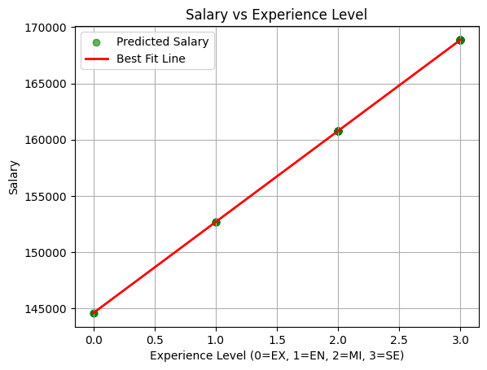

```python
# Preparing data for Linear Regression
model = LinearRegression()

columns_to_exclude = ["work_year", "salary_currency", "company_location", "salary"]

#Picking 30 random samples.
sample_encoded_df =  positions_df_encoded.sample(n=100)


#Independent variables (job_title (multiple due to One-Hot Encoding) and experience level)
#X = sample_encoded_df.drop(columns=columns_to_exclude)
X = sample_encoded_df['experience_level'].values.reshape(-1,1)
#Dependent variable
y = sample_encoded_df['salary']

#Training the model
X_train, X_test, y_train, y_test = train_test_split(X, y, test_size=0.2, random_state=42)

model.fit(X_train, y_train)

y_pred = model.predict(X)

x_range = np.linspace(X.min(), X.max(), 100).reshape(-1, 1)
y_pred_line = model.predict(x_range)


plt.scatter(X, y_pred, color='green', alpha=0.6, label='Predicted Salary')

# Plot best-fit line
plt.plot(x_range, y_pred_line, color='red', linewidth=2, label='Best Fit Line')

# Labels and title
plt.xlabel('Experience Level (0=EX, 1=EN, 2=MI, 3=SE)')
plt.ylabel('Salary')
plt.title('Salary vs Experience Level')
plt.legend()
plt.grid(True)
plt.show()
```

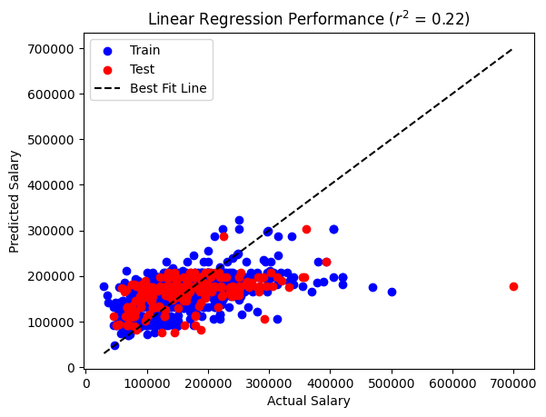

```python
sample_encoded_df =  positions_df_encoded.sample(n=1000)
X = sample_encoded_df.drop(columns=columns_to_exclude)
#Dependent variable
y = sample_encoded_df['salary']

#Training the model
X_train, X_test, y_train, y_test = train_test_split(X, y, test_size=0.2, random_state=42)

scaler = StandardScaler()
X_train = scaler.fit_transform(X_train)  # Fit on training, transform training
X_test = scaler.transform(X_test)

model.fit(X_train, y_train)

y_train_pred = model.predict(X_train)
y_test_pred = model.predict(X_test)

plt.scatter(y_train, y_train_pred, color='blue', label='Train')
plt.scatter(y_test, y_test_pred, color='red', label='Test')
plt.plot([y.min(), y.max()], [y.min(), y.max()], color='black', linestyle='--', label='Best Fit Line')
plt.xlabel('Actual Salary')
plt.ylabel('Predicted Salary')
plt.legend()
plt.title(f"Linear Regression Performance ($r^2$ = {r2(y_test, y_test_pred):.2f})")
plt.show()
```

# **Insights and Conclusion**